# Practica

Lucas Poveda

2023-11-23

Primero cargamos los paquetes:

```r
library(tidyverse)
library(caret)
library(gridExtra)
library(GEOquery)
```

Cargamos los datos

```r
tumor_data <- readRDS("Exercise.rds")
expr<-exprs(tumor_data)
fenotips<-pData(tumor_data)
tumor_data<-cbind(fenotips, as.data.frame(t(expr)))
dim(tumor_data)
```

```
## [1] 1016  930
```

```r
table(tumor_data$tumor)
```

```
##
## ADC SCC
## 364 352
```

```r
tumor_datacomplet<-filter(tumor_data, is.na(tumor_data$tumor)==FALSE)
tumor_data<-tumor_datacomplet
```

Pasamos al pre-processo

```r
glimpse(tumor_data[, 1:10])
```

```
## Rows: 716
## Columns: 10
## $ id                 <chr> "Sample-1", "Sample-2", "Sample-4", "Sample-7", "Sa…
## $ tumor              <chr> "ADC", "SCC", "SCC", "SCC", "SCC", "SCC", "ADC", "S…
## $ ENSG00000001561.6  <dbl> 2479.63957, 299.68805, 1122.71373, 236.92923, 16.54…
## $ ENSG00000001617.10 <dbl> 390.0312, 3525.5915, 3107.0170, 12023.6768, 3992.98…
## $ ENSG00000003096.12 <dbl> 169.95772, 2222.97017, 40.91347, 3192.76584, 1935.1…
## $ ENSG00000003147.16 <dbl> 3959.14332, 1392.01694, 1779.73591, 104.01771, 24.3…
## $ ENSG00000003436.13 <dbl> 13938.7121, 1007.1902, 1085.4103, 16928.8824, 1979.…
## $ ENSG00000003987.12 <dbl> 2736.75509, 41.71794, 36.10012, 21.18879, 76.86300,…
## $ ENSG00000003989.15 <dbl> 20540.9158, 127.7080, 563.1619, 179.1416, 1211.3219…
## $ ENSG00000004799.7  <dbl> 1438.10379, 639.39127, 611.29536, 297.60623, 38.917…
```

```r
rownames(tumor_data) <- tumor_data$sample_id
tumor_data <- tumor_data %>%
  mutate(tumor = as.factor(tumor)) %>%
  select(-id)
glimpse(tumor_data[, 1:5])
```

```
## Rows: 716
## Columns: 5
## $ tumor              <fct> ADC, SCC, SCC, SCC, SCC, SCC, ADC, SCC, ADC, SCC, S…
## $ ENSG00000001561.6  <dbl> 2479.63957, 299.68805, 1122.71373, 236.92923, 16.54…
## $ ENSG00000001617.10 <dbl> 390.0312, 3525.5915, 3107.0170, 12023.6768, 3992.98…
## $ ENSG00000003096.12 <dbl> 169.95772, 2222.97017, 40.91347, 3192.76584, 1935.1…
## $ ENSG00000003147.16 <dbl> 3959.14332, 1392.01694, 1779.73591, 104.01771, 24.3…
```

Centramos y escalamos para que todas las variables contribuyan proporcionalmente

```r
tumor_prep <- predict(preProcess(tumor_data, method = c("center", "scale")), tumor_data)
glimpse(tumor_prep[, 1:5])
```

```
## Rows: 716
## Columns: 5
## $ tumor              <fct> ADC, SCC, SCC, SCC, SCC, SCC, ADC, SCC, ADC, SCC, S…
## $ ENSG00000001561.6  <dbl> 0.65093221, -0.92492233, -0.32996931, -0.97028975, …
## $ ENSG00000001617.10 <dbl> -1.137103345, 0.007186812, -0.145567613, 3.10847472…
## $ ENSG00000003096.12 <dbl> -0.5406673, 1.7859459, -0.6869091, 2.8849843, 1.459…
## $ ENSG00000003147.16 <dbl> 1.41293139, -0.19549566, 0.04742876, -1.00248858, -…
```

Exploración de los datos:

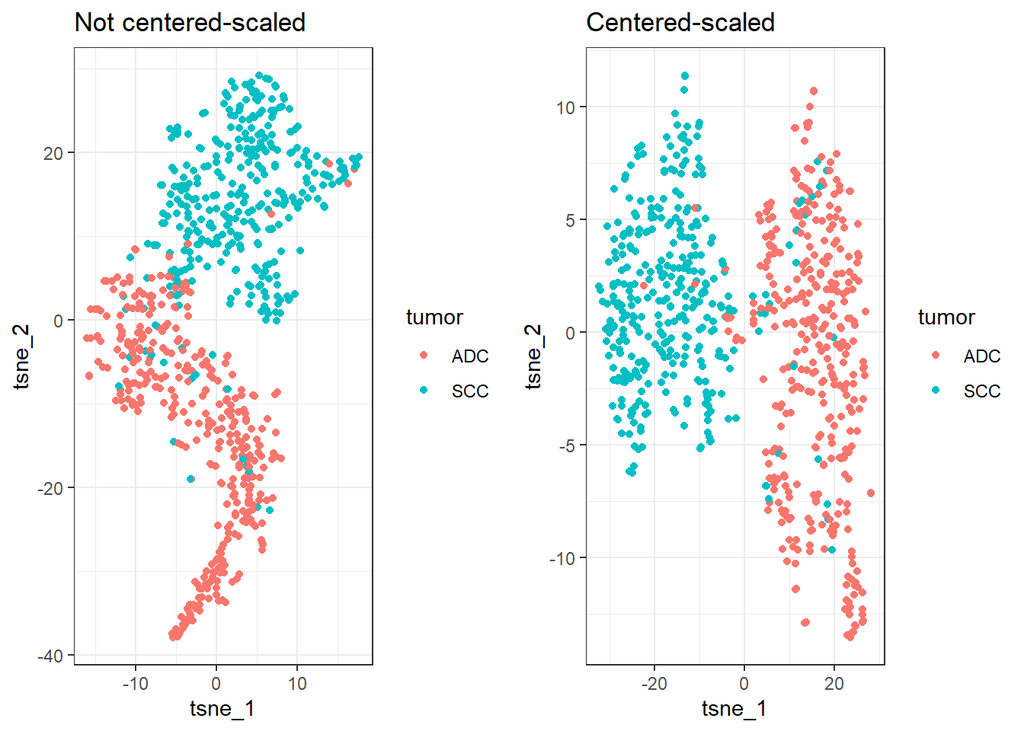

```r
tsne_df <- as.data.frame(Rtsne::Rtsne(tumor_data[, -1])$Y)

tsne_prep_df <- as.data.frame(Rtsne::Rtsne(tumor_prep[, -1])$Y)
rownames(tsne_df) <- rownames(tsne_prep_df) <- rownames(tumor_data)
colnames(tsne_df) <- colnames(tsne_prep_df) <- c('tsne_1', 'tsne_2')
tsne_df$tumor <- tsne_prep_df$tumor <- tumor_data$tumor
grid.arrange(
  ggplot(tsne_df, aes(x = tsne_1, y = tsne_2, color = tumor)) +
    geom_point() +
    ggtitle(label = 'Not centered-scaled') +
    theme_bw(),
  ggplot(tsne_prep_df, aes(x = tsne_1, y = tsne_2, color = tumor)) +
    geom_point() +
    ggtitle(label = 'Centered-scaled') +
    theme_bw(),
  ncol = 2)
```

Construimos y entrenamos los modelos:

Primero separamos la muestra en la muestra train y la muestra test:

```r
train <- createDataPartition(y = tumor_data$tumor, p = 0.7, list = FALSE, times = 1)
tumor_train <- tumor_data[train, ]
tumor_test  <- tumor_data[-train, ]
```

A continuación, definimos cómo se ajustará nuestro modelo durante el proceso de entrenamiento para optimizar la clasificación. En este caso, utilizamos la validación cruzada (CV) de 5 veces con 5 repeticiones. Además, si el algoritmo de aprendizaje requiere hiperparámetros, el CV se puede utilizar para estimar el valor adecuado.

Crearemos el objeto *fitcontrol* usando la función *trainControl()* para aplicar el mismo ajuste a cada algoritmo de aprendizaje.

```r
fitcontrol <- trainControl(method = "repeatedcv",
                           number = 5, repeats = 5,
                           classProbs = TRUE,
                           summaryFunction = twoClassSummary)
```

Aplicaremos los siguientes algoritmos de aprendizaje: **Logistic regression**, **K-nearest neighbors (KNN)**, **Linear discriminant analysis (LDA)** and **Support vector machines (SVM)**. Es importante que usemos los mismos datos de entrenamiento y de diseño experimental para poder comparar los diferentes métodos.

## Logistic regression

```r
glm_model <- suppressWarnings(
  train(tumor ~ ., data = tumor_train,
        method = "glm", trControl = fitcontrol))
glm_model
```

```
## Generalized Linear Model
##
## 502 samples
## 928 predictors
##   2 classes: 'ADC', 'SCC'
##
## No pre-processing
## Resampling: Cross-Validated (5 fold, repeated 5 times)
## Summary of sample sizes: 401, 402, 401, 402, 402, 402, ...
## Resampling results:
##
##   ROC        Sens       Spec
##   0.5310137  0.5364706  0.5270041
```

## K-nearest neighbors (KNN)

El método KNN necesita un hiperparámetro que es el número de vecinos (k) que se utilizarán en la clasificación. Podemos especificar el número de hiperparámetros a probar con *tuneLength*, y la métrica de resumen que se utilizará para seleccionar el modelo óptimo. En este caso, utilizamos 5 *k* diferentes y la métrica ROC para seleccionar la óptima.

```r
knn_model <- suppressWarnings(
  train(tumor ~ ., data = tumor_train,
        method = "knn", trControl = fitcontrol,
        tuneLength = 5, metric = "ROC"))
knn_model
```

```
## k-Nearest Neighbors
##
## 502 samples
## 928 predictors
##   2 classes: 'ADC', 'SCC'
##
## No pre-processing
## Resampling: Cross-Validated (5 fold, repeated 5 times)
## Summary of sample sizes: 402, 401, 402, 402, 401, 401, ...
## Resampling results across tuning parameters:
##
##   k   ROC        Sens       Spec
##    5  0.9650241  0.9505882  0.9238367
##    7  0.9719461  0.9560784  0.9165224
##    9  0.9746209  0.9647059  0.9108735
##   11  0.9743741  0.9709804  0.9036082
##   13  0.9760768  0.9733333  0.9003918
##
## ROC was used to select the optimal model using the largest value.
## The final value used for the model was k = 13.
```

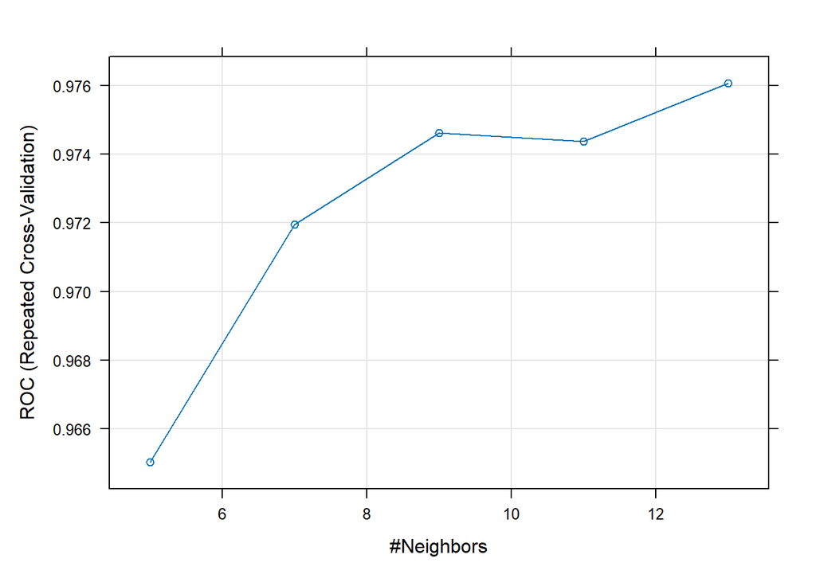

```r
plot(knn_model)
```

## Linear discriminant analysis (LDA)

```r
lda_model <- suppressWarnings(
  train(tumor ~ ., data = tumor_train,
        method = "lda", trControl = fitcontrol))
lda_model
```

```
## Linear Discriminant Analysis
##
## 502 samples
## 928 predictors
##   2 classes: 'ADC', 'SCC'
##
## No pre-processing
## Resampling: Cross-Validated (5 fold, repeated 5 times)
## Summary of sample sizes: 402, 401, 402, 402, 401, 401, ...
## Resampling results:
##
##   ROC        Sens       Spec
##   0.9748696  0.9482353  0.9279184
```

## Support vector machines (SVM)

```r
svm_model <- suppressWarnings(
  train(tumor ~ ., data = tumor_train,
        method = "svmPoly", trControl = fitcontrol,
        tuneLength = 3, metric = "ROC"))
svm_model
```

```
## Support Vector Machines with Polynomial Kernel
##
## 502 samples
## 928 predictors
##   2 classes: 'ADC', 'SCC'
##
## No pre-processing
## Resampling: Cross-Validated (5 fold, repeated 5 times)
## Summary of sample sizes: 401, 402, 402, 401, 402, 401, ...
## Resampling results across tuning parameters:
##
##   degree  scale  C     ROC        Sens       Spec
##   1       0.001  0.25  0.9873322  0.9756863  0.9352163
##   1       0.001  0.50  0.9881274  0.9725490  0.9344163
##   1       0.001  1.00  0.9876584  0.9741176  0.9327837
```

[output cut: 27 more lines]

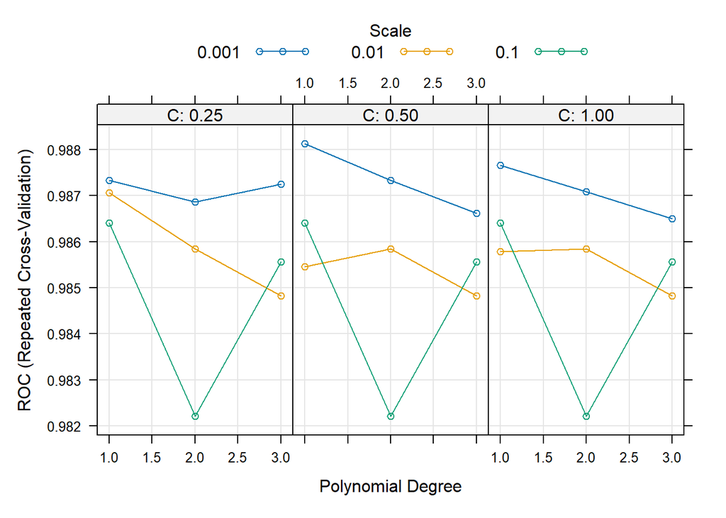

```r
plot(svm_model)
```

UNA VEZ HEMOS CREADO LOS DIFERENTES MODELOS, TOCA COMPARARLOS:

# Compare models

Compararemos los modelos en base a 3 metricas: Sensivilidad, Especificidad y ROC. In order to test whether one model performs significantly better than the others, a comparison based on three metrics (Sensitivity, Specificity and ROC) can be applied. La sensibilidad es la tasa de verdaderos positivos, que se refiere a la probabilidad de que una prueba positiva sea realmente positiva. Mientras que la especificidad es la tasa negativa verdadera, que se refiere a la probabilidad de que una prueba negativa sea realmente negativa. El valor ROC es el área bajo la curva ROC (sensibilidad frente a 1-especificidad) que se usa comúnmente para medir el rendimiento de los clasificadores binarios, por lo que cuanto más altos sean los valores de ROC, mejor será el modelo.

```r
model_list <- list(GLM = glm_model, KNN = knn_model, LDA = lda_model, SVM = svm_model)

models_res <- resamples(model_list)
summary(models_res)
```

```
##
## Call:
## summary.resamples(object = models_res)
##
## Models: GLM, KNN, LDA, SVM
## Number of resamples: 25
##
## ROC
##          Min.   1st Qu.    Median      Mean   3rd Qu.      Max. NA's
## GLM 0.4219688 0.4807923 0.5130052 0.5310137 0.5730292 0.6443137    0
## KNN 0.9523810 0.9651861 0.9779912 0.9760768 0.9867947 0.9968627    0
## LDA 0.9455782 0.9687875 0.9799920 0.9748696 0.9855942 0.9968627    0
## SVM 0.9715886 0.9819928 0.9878431 0.9881274 0.9963986 0.9996078    0
##
## Sens
##          Min.   1st Qu.    Median      Mean   3rd Qu.      Max. NA's
## GLM 0.4117647 0.4705882 0.5490196 0.5364706 0.5882353 0.7254902    0
## KNN 0.9411765 0.9607843 0.9803922 0.9733333 1.0000000 1.0000000    0
## LDA 0.8627451 0.9411765 0.9411765 0.9482353 0.9607843 1.0000000    0
## SVM 0.8823529 0.9607843 0.9803922 0.9725490 1.0000000 1.0000000    0
##
## Spec
##          Min.   1st Qu.    Median      Mean   3rd Qu.      Max. NA's
## GLM 0.3000000 0.4800000 0.5306122 0.5270041 0.6000000 0.6600000    0
## KNN 0.8367347 0.8775510 0.8979592 0.9003918 0.9200000 0.9795918    0
## LDA 0.8367347 0.9183673 0.9387755 0.9279184 0.9591837 1.0000000    0
## SVM 0.8979592 0.9183673 0.9200000 0.9344163 0.9400000 0.9800000    0
```

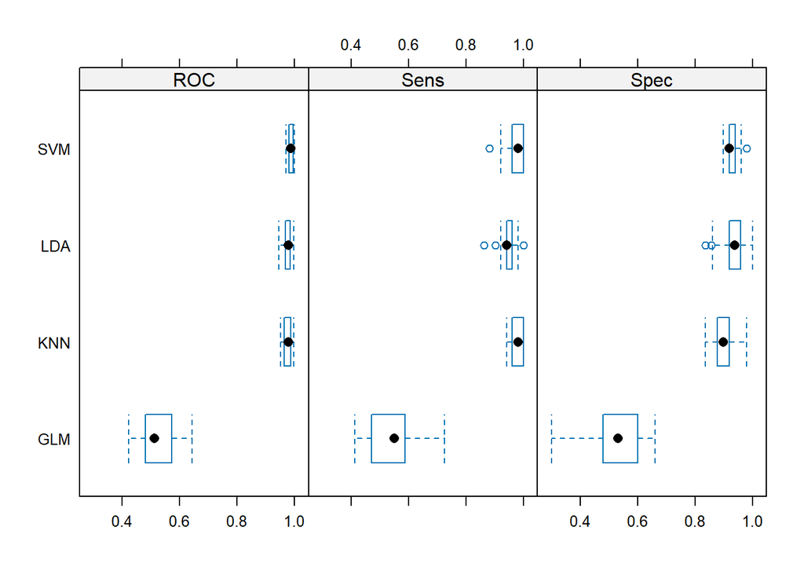

```r
bwplot(models_res)
```

```r
models_diff <- diff(models_res)
summary(models_diff)
```

```
##
## Call:
## summary.diff.resamples(object = models_diff)
##
## p-value adjustment: bonferroni
## Upper diagonal: estimates of the difference
## Lower diagonal: p-value for H0: difference = 0
##
## ROC
##     GLM       KNN       LDA       SVM
## GLM           -0.445063 -0.443856 -0.457114
## KNN < 2.2e-16            0.001207 -0.012051
## LDA < 2.2e-16 1.000000            -0.013258
## SVM < 2.2e-16 0.015154  0.001128
##
## Sens
##     GLM       KNN        LDA        SVM
## GLM           -0.4368627 -0.4117647 -0.4360784
## KNN < 2.2e-16             0.0250980  0.0007843
## LDA < 2.2e-16 0.003597              -0.0243137
## SVM < 2.2e-16 1.000000   0.106912
##
## Spec
##     GLM       KNN       LDA       SVM
## GLM           -0.373388 -0.400914 -0.407412
## KNN 4.580e-16           -0.027527 -0.034024
## LDA 5.185e-16 0.126869            -0.006498
## SVM < 2.2e-16 0.003688  1.000000
```

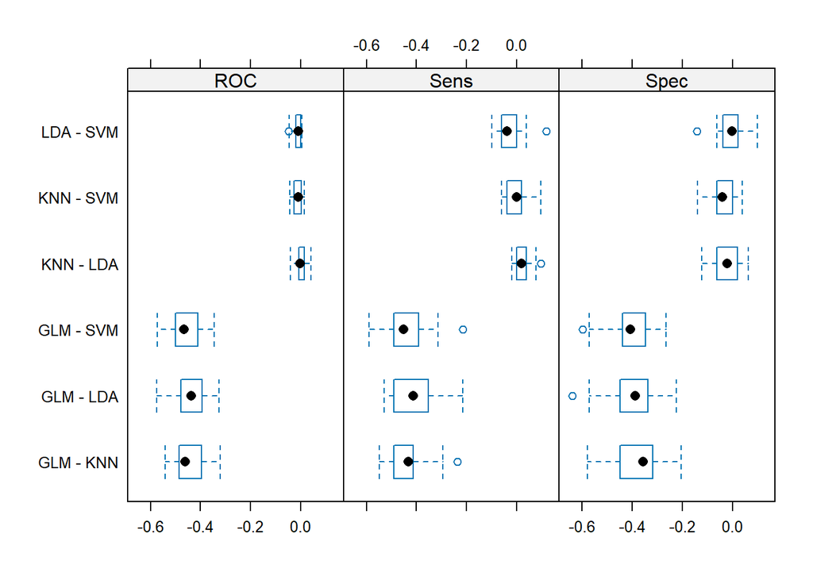

```r
bwplot(models_diff)
```

Confirmamos que nuestros modelos KNN, SVM y LDA tienen valores significativos altos de ROC, sensibilidad i especificidad comparados con GLM. Este resultado indica que SVM es nuestro mejor modelo

# Test models

```r
tsne_test <- tsne_df[rownames(tumor_test),]
p1 <- ggplot() +
  geom_point(tsne_df,
             mapping = aes(x = tsne_1, y = tsne_2),
             color = 'gray') +
  geom_point(tsne_test,
             mapping = aes(x = tsne_1, y = tsne_2, color = tumor)) +
  ggtitle(label = 'True labels') +
  theme_bw()
```

## Logistic regression

```r
glm_predict <- predict(glm_model, tumor_test)
confusionMatrix(glm_predict, tumor_test$tumor)
```

```
## Confusion Matrix and Statistics
##
##           Reference
## Prediction ADC SCC
##        ADC  58  51
##        SCC  51  54
##
##                Accuracy : 0.5234
##                  95% CI : (0.4542, 0.5919)
##     No Information Rate : 0.5093
##     P-Value [Acc > NIR] : 0.3664
##
##                   Kappa : 0.0464
##
##  Mcnemar's Test P-Value : 1.0000
##
##             Sensitivity : 0.5321
##             Specificity : 0.5143
##          Pos Pred Value : 0.5321
##          Neg Pred Value : 0.5143
##              Prevalence : 0.5093
##          Detection Rate : 0.2710
##    Detection Prevalence : 0.5093
##       Balanced Accuracy : 0.5232
##
##        'Positive' Class : ADC
##
```

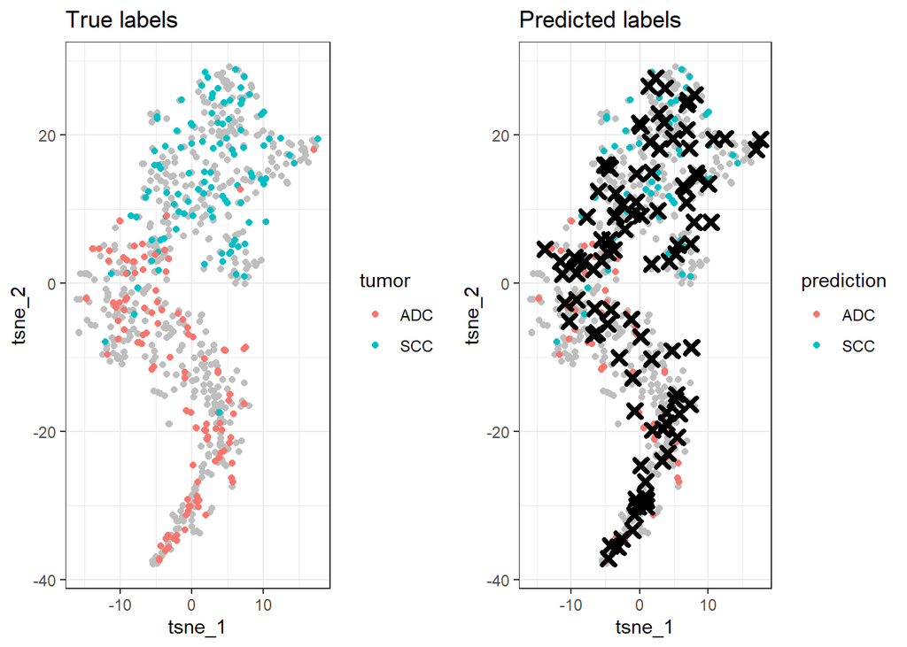

```r
tsne_test$prediction <- glm_predict
p2 <- ggplot() +
  geom_point(tsne_df,
             mapping = aes(x = tsne_1, y = tsne_2),
             color = 'gray') +
  geom_point(data = tsne_test,
             mapping = aes(x = tsne_1, y = tsne_2, color = prediction)) +
  geom_point(data = subset(tsne_test, prediction != tumor),
             mapping = aes(x = tsne_1, y = tsne_2),
             color = 'black', shape = 4, size = 2, stroke = 2) +
  ggtitle(label = 'Predicted labels') +
  theme_bw()
grid.arrange(p1, p2, ncol = 2)
```

## K-nearest neighbors (KNN)

```r
knn_predict <- predict(knn_model, tumor_test)
confusionMatrix(knn_predict, tumor_test$tumor)
```

```
## Confusion Matrix and Statistics
##
##           Reference
## Prediction ADC SCC
##        ADC 103   9
##        SCC   6  96
##
##                Accuracy : 0.9299
##                  95% CI : (0.887, 0.9602)
##     No Information Rate : 0.5093
##     P-Value [Acc > NIR] : <2e-16
##
##                   Kappa : 0.8597
##
##  Mcnemar's Test P-Value : 0.6056
##
##             Sensitivity : 0.9450
##             Specificity : 0.9143
##          Pos Pred Value : 0.9196
##          Neg Pred Value : 0.9412
##              Prevalence : 0.5093
##          Detection Rate : 0.4813
##    Detection Prevalence : 0.5234
##       Balanced Accuracy : 0.9296
##
##        'Positive' Class : ADC
##
```

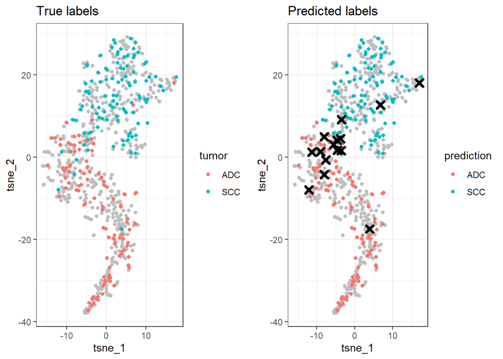

```r
tsne_test$prediction <- knn_predict
p2 <- ggplot() +
  geom_point(tsne_df,
             mapping = aes(x = tsne_1, y = tsne_2),
             color = 'gray') +
  geom_point(data = tsne_test,
             mapping = aes(x = tsne_1, y = tsne_2, color = prediction)) +
  geom_point(data = subset(tsne_test, prediction != tumor),
             mapping = aes(x = tsne_1, y = tsne_2),
             color = 'black', shape = 4, size = 2, stroke = 2) +
  ggtitle(label = 'Predicted labels') +
  theme_bw()
grid.arrange(p1, p2, ncol = 2)
```

## Linear discriminant analysis (LDA)

```r
lda_predict <- predict(lda_model, tumor_test)
confusionMatrix(lda_predict, tumor_test$tumor)
```

```
## Confusion Matrix and Statistics
##
##           Reference
## Prediction ADC SCC
##        ADC 105  11
##        SCC   4  94
##
##                Accuracy : 0.9299
##                  95% CI : (0.887, 0.9602)
##     No Information Rate : 0.5093
##     P-Value [Acc > NIR] : <2e-16
##
##                   Kappa : 0.8596
##
##  Mcnemar's Test P-Value : 0.1213
##
##             Sensitivity : 0.9633
##             Specificity : 0.8952
##          Pos Pred Value : 0.9052
##          Neg Pred Value : 0.9592
##              Prevalence : 0.5093
##          Detection Rate : 0.4907
##    Detection Prevalence : 0.5421
##       Balanced Accuracy : 0.9293
##
##        'Positive' Class : ADC
##
```

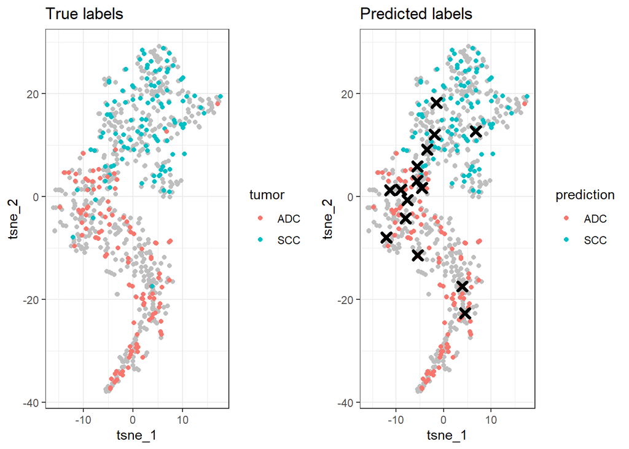

```r
tsne_test$prediction <- lda_predict
p2 <- ggplot() +
  geom_point(tsne_df,
             mapping = aes(x = tsne_1, y = tsne_2),
             color = 'gray') +
  geom_point(data = tsne_test,
             mapping = aes(x = tsne_1, y = tsne_2, color = prediction)) +
  geom_point(data = subset(tsne_test, prediction != tumor),
             mapping = aes(x = tsne_1, y = tsne_2),
             color = 'black', shape = 4, size = 2, stroke = 2) +
  ggtitle(label = 'Predicted labels') +
  theme_bw()
grid.arrange(p1, p2, ncol = 2)
```

## Support vector machines (SVM)

```r
svm_predict <- predict(svm_model, tumor_test)
confusionMatrix(svm_predict, tumor_test$tumor)
```

```
## Confusion Matrix and Statistics
##
##           Reference
## Prediction ADC SCC
##        ADC 104   9
##        SCC   5  96
##
##                Accuracy : 0.9346
##                  95% CI : (0.8927, 0.9638)
##     No Information Rate : 0.5093
##     P-Value [Acc > NIR] : <2e-16
##
##                   Kappa : 0.869
##
##  Mcnemar's Test P-Value : 0.4227
##
##             Sensitivity : 0.9541
##             Specificity : 0.9143
##          Pos Pred Value : 0.9204
##          Neg Pred Value : 0.9505
##              Prevalence : 0.5093
##          Detection Rate : 0.4860
##    Detection Prevalence : 0.5280
##       Balanced Accuracy : 0.9342
##
##        'Positive' Class : ADC
##
```

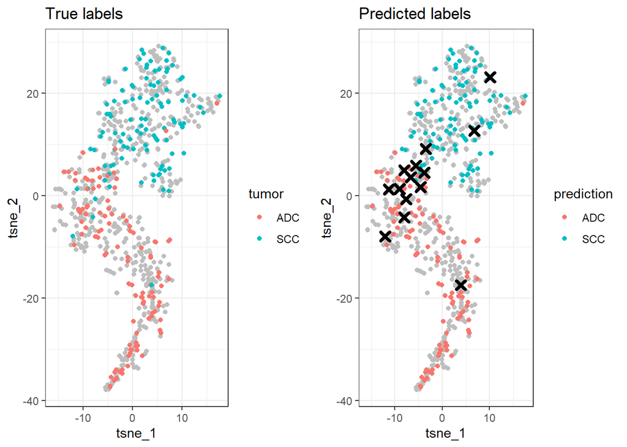

```r
tsne_test$prediction <- svm_predict
p2 <- ggplot() +
  geom_point(tsne_df,
             mapping = aes(x = tsne_1, y = tsne_2),
             color = 'gray') +
  geom_point(data = tsne_test,
             mapping = aes(x = tsne_1, y = tsne_2, color = prediction)) +
  geom_point(data = subset(tsne_test, prediction != tumor),
             mapping = aes(x = tsne_1, y = tsne_2),
             color = 'black', shape = 4, size = 2, stroke = 2) +
  ggtitle(label = 'Predicted labels') +
  theme_bw()
grid.arrange(p1, p2, ncol = 2)
```

## E N T R E G A:

```r
write.table(svm_predict,file="1597330(RNA).txt",sep="\t")
#Aprovecho los datos que tenian NA y que hemos descartado para la elaboración del modelo para predecir sus posibles valores perdidos en función del modelo entrenado
tumor_data2 <- readRDS("Exercise.rds")
expr<-exprs(tumor_data2)
fenotips<-pData(tumor_data2)
tumor_data2<-cbind(fenotips, as.data.frame(t(expr)))

tumor_dataNAs<-filter(tumor_data2, is.na(tumor_data2$tumor)==TRUE)


svm_predict2<-predict(svm_model, tumor_dataNAs)
write.table(svm_predict2,file="1597330NAs(RNA).txt",sep="\t")
prediccion<-predict(svm_model,)
```